# snRNA-seq TSC2: Case-control analysis - Neurons - Cellchat Ligand receptor interactions

Frederik Nørby Friis Sørensen, University of Copenhagen

07-nov-2024

### Adapted from cellchat v2 tutorial

# Setup

```r
library(CellChat)
library(dplyr)
library(magrittr)
ptm = Sys.time()
library(CellChat)
library(patchwork)
library(reticulate)
```

# Data directories

```r
setwd(data.dir)
```

# Load data

```r
cms <- readRDS("../cms_neurons.rds")
metadata <- readRDS("metadata_cell_2.rds")
annotation <- readRDS("../../3.all_cells/annotation_neurons.rds")
anno <- annotation$l4
```

# Prepare data

```r
dat.mat <- cms %>%
  sccore:::mergeCountMatrices() %>%
  Matrix::drop0() %>%
  .[,match(names(anno), colnames(.), nomatch = FALSE)] %>% t()
```

```r
cell.use.control <- rownames(metadata)[metadata$condition=="Control"]
cell.use.tsc <- rownames(metadata)[metadata$condition=="TSC2"]
```

```r
data.input.control <- dat.mat[cell.use.control, ] %>% Matrix::t() %>% normalizeData()
```

[output not shown]

```r
meta.control <- metadata[cell.use.control, ]
meta.control %<>% dplyr::rename(samples=sample)
unique(meta.control$annol4)
```

```
 [1] L2_CUX2_LAMP5_PDGFD      L5_6_FEZF2_LRRK1_PCP4    L3_CUX2_SPOCK3_PRSS12    L2_3_CUX2_FREM3_NTNG1    TBD                      L5_6_FEZF2_LRRK1_SEMA3E
 [7] L4_RORB_SCHLAP1_ARHGAP15 L5_6_THEMIS_SEMA3A       L5_6_FEZF2_TLE4_ABO      L5_6_FEZF2_TLE4_SCUBE1   L5_6_FEZF2_TLE4_HTR2C    L4_RORB_SCHLAP1_MME
[13] L5_6_THEMIS_NR4A2_NTNG2  L4_RORB_SCHLAP1_MET      PVALB_BTBD11             PVALB_LGR5               PVALB_MEPE               SST_CALB1
[19] SST_NPY                  PVALB_UNC5B              SST_TH                   ID2_CHRNA7_CNR1          ID2_CHRNA7_PAX6          VIP_TYR
[25] ID2_LAMP5_CRH            VIP_CRH                  VIP_ABI3BP               ID2_CHRNA7_NCKAP5        ID2_LAMP5_MEIS2          VIP_SEMA3C
[31] VIP_TRPM3_SSTR1          ID2_LAMP5_NMBR           SST_ISOC_THSD7B          SST_NOS1                 SST_TAC3                 SST_STK32A
[37] ID2_LAMP5_NOS1           VIP_CBLN1                VIP_NRG1                 Neu_dev_THY1
40 Levels: ID2_CHRNA7_CNR1 ID2_CHRNA7_NCKAP5 ID2_CHRNA7_PAX6 ID2_LAMP5_CRH ID2_LAMP5_MEIS2 ID2_LAMP5_NMBR ID2_LAMP5_NOS1 L2_3_CUX2_FREM3_NTNG1 ... VIP_TYR
```

```r
meta.tsc <- metadata[cell.use.tsc, ]
meta.tsc %<>% dplyr::rename(samples=sample)
unique(meta.tsc$annol4)
```

```
 [1] L5_6_THEMIS_SEMA3A       L2_CUX2_LAMP5_PDGFD      L2_3_CUX2_FREM3_NTNG1    L5_6_FEZF2_TLE4_SCUBE1   L5_6_FEZF2_LRRK1_PCP4    L5_6_FEZF2_TLE4_ABO
 [7] TBD                      L5_6_FEZF2_LRRK1_SEMA3E  L3_CUX2_SPOCK3_PRSS12    L4_RORB_SCHLAP1_MME      L5_6_FEZF2_TLE4_HTR2C    L4_RORB_SCHLAP1_MET
[13] L4_RORB_SCHLAP1_ARHGAP15 PVALB_MEPE               PVALB_BTBD11             PVALB_LGR5               SST_TH                   PVALB_UNC5B
[19] SST_CALB1                VIP_TRPM3_SSTR1          VIP_TYR                  ID2_CHRNA7_PAX6          VIP_SEMA3C               ID2_CHRNA7_CNR1
[25] ID2_LAMP5_CRH            ID2_CHRNA7_NCKAP5        VIP_CRH                  VIP_ABI3BP               VIP_NRG1                 ID2_LAMP5_MEIS2
[31] ID2_LAMP5_NMBR           L5_6_THEMIS_NR4A2_NTNG2  SST_NOS1                 SST_NPY                  SST_TAC3                 SST_STK32A
[37] SST_ISOC_THSD7B          ID2_LAMP5_NOS1           VIP_CBLN1                Neu_dev_THY1
40 Levels: ID2_CHRNA7_CNR1 ID2_CHRNA7_NCKAP5 ID2_CHRNA7_PAX6 ID2_LAMP5_CRH ID2_LAMP5_MEIS2 ID2_LAMP5_NMBR ID2_LAMP5_NOS1 L2_3_CUX2_FREM3_NTNG1 ... VIP_TYR
```

# Create object

```r
cellchat.control <- createCellChat(object = data.input.control, meta = meta.control, group.by = "annol4")
```

```
[1] "Create a CellChat object from a data matrix"
Set cell identities for the new CellChat object
The cell groups used for CellChat analysis are  ID2_CHRNA7_CNR1, ID2_CHRNA7_NCKAP5, ID2_CHRNA7_PAX6, ID2_LAMP5_CRH, ID2_LAMP5_MEIS2, ID2_LAMP5_NMBR, ID2_LAMP5_NOS1, L2_3_CUX2_FREM3_NTNG1, L2_CUX2_LAMP5_PDGFD, L3_CUX2_SPOCK3_PRSS12, L4_RORB_SCHLAP1_ARHGAP15, L4_RORB_SCHLAP1_MET, L4_RORB_SCHLAP1_MME, …
```

```r
cellchat.tsc <- createCellChat(object = data.input.tsc, meta = meta.tsc, group.by = "annol4")
```

```
[1] "Create a CellChat object from a data matrix"
Set cell identities for the new CellChat object
The cell groups used for CellChat analysis are  ID2_CHRNA7_CNR1, ID2_CHRNA7_NCKAP5, ID2_CHRNA7_PAX6, ID2_LAMP5_CRH, ID2_LAMP5_MEIS2, ID2_LAMP5_NMBR, ID2_LAMP5_NOS1, L2_3_CUX2_FREM3_NTNG1, L2_CUX2_LAMP5_PDGFD, L3_CUX2_SPOCK3_PRSS12, L4_RORB_SCHLAP1_ARHGAP15, L4_RORB_SCHLAP1_MET, L4_RORB_SCHLAP1_MME, …
```

# Select DB

```r
CellChatDB<- CellChatDB.human
dplyr::glimpse(CellChatDB$interaction)
```

```
Rows: 3,233
Columns: 28
$ interaction_name         <chr> "TGFB1_TGFBR1_TGFBR2", "TGFB2_TGFBR1_TGFBR2", "TGFB3_TGFBR1_TGFBR2", "TGFB1_ACVR1B_TGFBR2", "TGFB1_ACVR1C_TGFBR2", "TGFB2_ACVR1B_TGFB…
$ pathway_name             <chr> "TGFb", "TGFb", "TGFb", "TGFb", "TGFb", "TGFb", "TGFb", "TGFb", "TGFb", "TGFb", "TGFb", "TGFb", "BMP", "BMP", "BMP", "BMP", "BMP", "B…
$ ligand                   <chr> "TGFB1", "TGFB2", "TGFB3", "TGFB1", "TGFB1", "TGFB2", "TGFB2", "TGFB3", "TGFB3", "TGFB1", "TGFB2", "TGFB3", "BMP2", "BMP2", "BMP2", "…
$ receptor                 <chr> "TGFbR1_R2", "TGFbR1_R2", "TGFbR1_R2", "ACVR1B_TGFbR2", "ACVR1C_TGFbR2", "ACVR1B_TGFbR2", "ACVR1C_TGFbR2", "ACVR1B_TGFbR2", "ACVR1C_T…
$ agonist                  <chr> "TGFb agonist", "TGFb agonist", "TGFb agonist", "TGFb agonist", "TGFb agonist", "TGFb agonist", "TGFb agonist", "TGFb agonist", "TGFb…
$ antagonist               <chr> "TGFb antagonist", "TGFb antagonist", "TGFb antagonist", "TGFb antagonist", "TGFb antagonist", "TGFb antagonist", "TGFb antagonist", …
$ co_A_receptor            <chr> "", "", "", "", "", "", "", "", "", "", "", "", "", "", "", "", "", "", "", "", "", "", "", "", "", "", "", "", "", "", "", "", "", "…
$ co_I_receptor            <chr> "TGFb inhibition receptor", "TGFb inhibition receptor", "TGFb inhibition receptor", "TGFb inhibition receptor", "TGFb inhibition rece…
$ evidence                 <chr> "KEGG: hsa04350", "KEGG: hsa04350", "KEGG: hsa04350", "PMID: 27449815", "PMID: 27449815", "PMID: 27449815", "PMID: 27449815", "PMID: …
$ annotation               <chr> "Secreted Signaling", "Secreted Signaling", "Secreted Signaling", "Secreted Signaling", "Secreted Signaling", "Secreted Signaling", "…
$ interaction_name_2       <chr> "TGFB1 - (TGFBR1+TGFBR2)", "TGFB2 - (TGFBR1+TGFBR2)", "TGFB3 - (TGFBR1+TGFBR2)", "TGFB1 - (ACVR1B+TGFBR2)", "TGFB1 - (ACVR1C+TGFBR2)"…
$ is_neurotransmitter      <lgl> FALSE, FALSE, FALSE, FALSE, FALSE, FALSE, FALSE, FALSE, FALSE, FALSE, FALSE, FALSE, FALSE, FALSE, FALSE, FALSE, FALSE, FALSE, FALSE, …
$ ligand.symbol            <chr> "TGFB1", "TGFB2", "TGFB3", "TGFB1", "TGFB1", "TGFB2", "TGFB2", "TGFB3", "TGFB3", "TGFB1", "TGFB2", "TGFB3", "BMP2", "BMP2", "BMP2", "…
$ ligand.family            <chr> "TGF-beta", "TGF-beta", "TGF-beta", "TGF-beta", "TGF-beta", "TGF-beta", "TGF-beta", "TGF-beta", "TGF-beta", "TGF-beta", "TGF-beta", "…
$ ligand.location          <chr> "Extracellular matrix, Secreted, Extracellular space", "Extracellular matrix, Secreted, Extracellular space", "Extracellular matrix, …
$ ligand.keyword           <chr> "Disease variant, Signal, Reference proteome, Extracellular matrix, Disulfide bond, Secreted, Mitogen, Growth factor, Direct protein …
$ ligand.secreted_type     <chr> "growth factor", "growth factor", "cytokine;growth factor", "growth factor", "growth factor", "growth factor", "growth factor", "cyto…
$ ligand.transmembrane     <lgl> FALSE, FALSE, TRUE, FALSE, FALSE, FALSE, FALSE, TRUE, TRUE, FALSE, FALSE, TRUE, FALSE, FALSE, FALSE, FALSE, FALSE, FALSE, FALSE, FALS…
$ receptor.symbol          <chr> "TGFBR2, TGFBR1", "TGFBR2, TGFBR1", "TGFBR2, TGFBR1", "TGFBR2, ACVR1B", "TGFBR2, ACVR1C", "TGFBR2, ACVR1B", "TGFBR2, ACVR1C", "TGFBR2…
$ receptor.family          <chr> "Protein kinase superfamily, TKL Ser/Thr protein kinase", "Protein kinase superfamily, TKL Ser/Thr protein kinase", "Protein kinase s…
$ receptor.location        <chr> "Cell membrane, Secreted, Membrane raft, Cell surface, Cell junction, Tight junction", "Cell membrane, Secreted, Membrane raft, Cell …
$ receptor.keyword         <chr> "Membrane, Secreted, Disulfide bond, Kinase, Transmembrane, Differentiation, ATP-binding, Receptor, Alternative splicing, Aortic aneu…
$ receptor.surfaceome_main <chr> "Receptors", "Receptors", "Receptors", "Receptors", "Receptors", "Receptors", "Receptors", "Receptors", "Receptors", "Receptors", "Re…
$ receptor.surfaceome_sub  <chr> "Act.TGFB;Kinase", "Act.TGFB;Kinase", "Act.TGFB;Kinase", "Act.TGFB;Kinase", "Act.TGFB;Kinase", "Act.TGFB;Kinase", "Act.TGFB;Kinase", …
$ receptor.adhesome        <chr> "", "", "", "", "", "", "", "", "", "", "", "", "", "", "", "", "", "", "", "", "", "", "", "", "", "", "", "", "", "", "", "", "", "…
$ receptor.secreted_type   <chr> "", "", "", "", "", "", "", "", "", "", "", "", "", "", "", "", "", "", "", "", "", "", "", "", "", "", "", "", "", "", "", "", "", "…
$ receptor.transmembrane   <lgl> TRUE, TRUE, TRUE, TRUE, TRUE, TRUE, TRUE, TRUE, TRUE, TRUE, TRUE, TRUE, TRUE, TRUE, TRUE, TRUE, TRUE, TRUE, TRUE, TRUE, TRUE, TRUE, T…
$ version                  <chr> "CellChatDB v1", "CellChatDB v1", "CellChatDB v1", "CellChatDB v1", "CellChatDB v1", "CellChatDB v1", "CellChatDB v1", "CellChatDB v1…
```

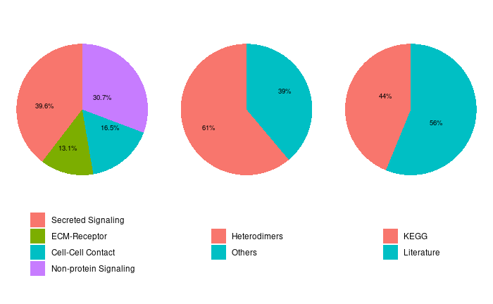

```r
showDatabaseCategory(CellChatDB)
```

```r
CellChatDB.use <- CellChatDB
```

```r
cellchat.tsc@DB <- CellChatDB.use
cellchat.control@DB <- CellChatDB.use
```

```r
saveRDS(cellchat.control, "cellchat.control.rds",compress=F)
saveRDS(cellchat.tsc, "cellchat.tsc.rds",compress=F)
```

#Calculate control

```r
cellchat <- readRDS("cellchat.control.rds")
```

# Calculate (this is run in an R session from terminal due to problems with multithreading)

#Calculate TSC

# Calculate (this is run in an R session from terminal due to problems with multithreading)

# Plotting

Load object

#Now both cellchat networks has been calculated for both conditions, we start the cellchat tutorial for multiple datasets:

## Create a directory to save figures

```r
data.dir <- 'Cellchat/comparison'
dir.create(data.dir)
setwd(data.dir)
```

# Load CellChat object of each dataset and merge them together

Users need to first run CellChat on each dataset separately and then merge different CellChat objects together. Please do `updateCellChat` if the CellChat objects are obtained using the earlier version (< 1.6.0).

```r
# Users can now export the merged CellChat object and the list of the two separate objects for later use
saveRDS(object.list, file = "Cellchat/comparison/cellchat_object_list.rds")
saveRDS(cellchat, file = "Cellchat/comparison/cellchat_control_tsc.rds")
```

# Part I: Identify altered interactions and cell populations

CellChat employs a top-down approach, i.e., starting with the big picture and then refining it in a greater detail on the signaling mechanisms, to identify signaling changes at different levels, including altered interactions, cell populations, signaling pathways and ligand-receptor pairs. First, CellChat starts with a big picture to answer the following questions:

- Whether the cell-cell communication is enhanced or not
- The interaction between which cell types is significantly changed
- How the major sources and targets change from one condition to another

## Compare the total number of interactions and interaction strength

To answer the question on whether the cell-cell communication is enhanced or not, CellChat compares the total number of interactions and interaction strength of the inferred cell-cell communication networks from different biological conditions.

# Load cellchat objects, if you dont want to run all the models above just load from objects in folder

```r
object.list <- readRDS("comparison/cellchat_object_list.rds")
cellchat <- readRDS("comparison/cellchat_control_tsc.rds")
```

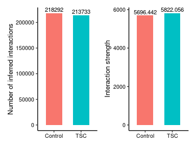

```r
ptm = Sys.time()
gg1 <- compareInteractions(cellchat, show.legend = F, group = c(1,2))
gg2 <- compareInteractions(cellchat, show.legend = F, group = c(1,2), measure = "weight")
gg1 + gg2
```

## Compare the number of interactions and interaction strength among different cell populations

### (B) Heatmap showing differential number of interactions or interaction strength among different cell populations across two datasets

CellChat can also show differential number of interactions or interaction strength in greater details using a heatmap. The top colored bar plot represents the sum of each column of the absolute values displayed in the heatmap (incoming signaling). The right colored bar plot represents the sum of each row of the absolute values (outgoing signaling). Therefore, the bar height indicates the degree of change in terms of the number of interactions or interaction strength between the two conditions. In the colorbar, $\color{red}{\text{red}}$ (or $\color{blue}{\text{blue}}$) represents $\color{red}{\text{increased}}$ (or $\color{blue}{\text{decreased}}$) signaling in the second dataset compared to the first one.

### Fig. 5e + Extended Data Fig. 16

```r
cells_use <- c( "L2_CUX2_LAMP5_PDGFD","L2_3_CUX2_FREM3_NTNG1", "L3_CUX2_SPOCK3_PRSS12", "L4_RORB_SCHLAP1_ARHGAP15", "L4_RORB_SCHLAP1_MET",
                "L4_RORB_SCHLAP1_MME", "L5_6_FEZF2_LRRK1_PCP4", "L5_6_FEZF2_LRRK1_SEMA3E", "L5_6_FEZF2_TLE4_ABO", "L5_6_FEZF2_TLE4_HTR2C",
                "L5_6_FEZF2_TLE4_SCUBE1", "L5_6_THEMIS_NR4A2_NTNG2", "L5_6_THEMIS_SEMA3A", "ID2_CHRNA7_CNR1",
                "ID2_CHRNA7_NCKAP5", "ID2_CHRNA7_PAX6", "ID2_LAMP5_CRH", "ID2_LAMP5_MEIS2", "ID2_LAMP5_NMBR", "ID2_LAMP5_NOS1", "VIP_ABI3BP", "VIP_CBLN1", "VIP_CRH",
                "VIP_NRG1", "VIP_SEMA3C", "VIP_TRPM3_SSTR1", "VIP_TYR", "PVALB_BTBD11", "PVALB_LGR5", "PVALB_MEPE", "PVALB_UNC5B", "SST_CALB1", "SST_ISOC_THSD7B", "SST_NOS1",
                "SST_NPY", "SST_STK32A", "SST_TAC3", "SST_TH")

gg1 <- netVisual_heatmap(cellchat, row.show = cells_use, col.show = cells_use)
gg2 <- netVisual_heatmap(cellchat, measure = "weight",row.show = cells_use, col.show = cells_use)
```

### Fig. 5e

```r
png("figures/Cellchat_number_of_interactions.png",width=11,height=10,units="in",res=1200)
gg1
dev.off()
```

### Extended Data Fig. 16

```r
png("figures/Cellchat_interaction_strength.png",width=11,height=10,units="in",res=1200)
gg2
dev.off()
```